# Homework 4

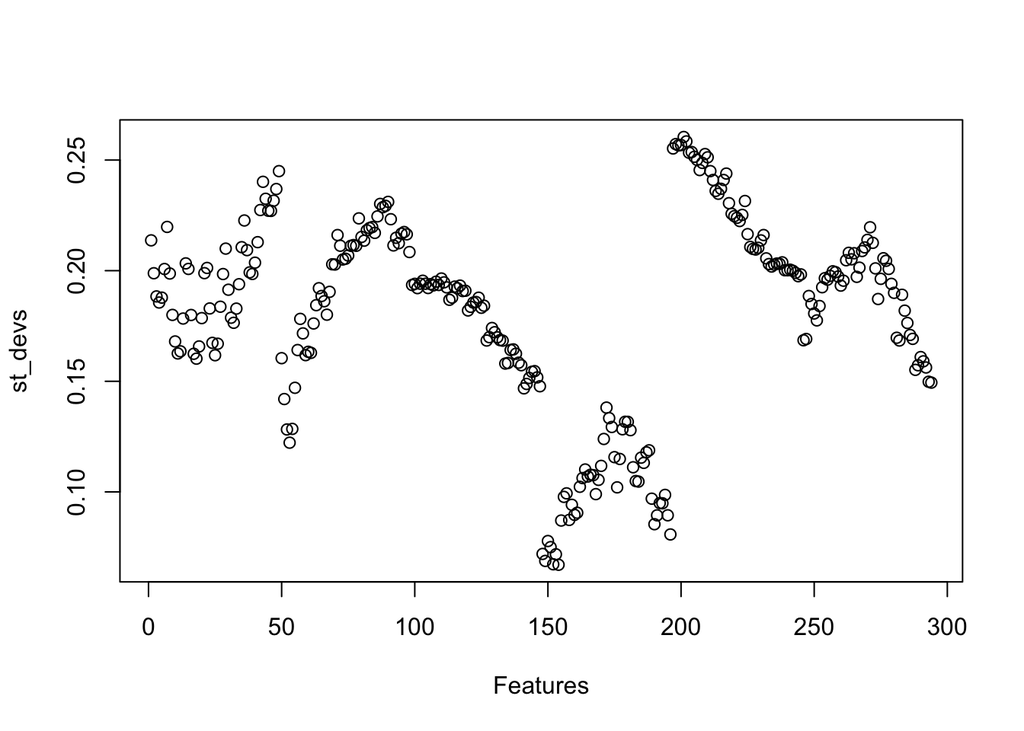

```r
# Plot stdevs
st_devs <- sqrt(colMeans((sweep(data[,-c(295:300)], 2, means))^2))
plot(st_devs, xlab = "Features")
```

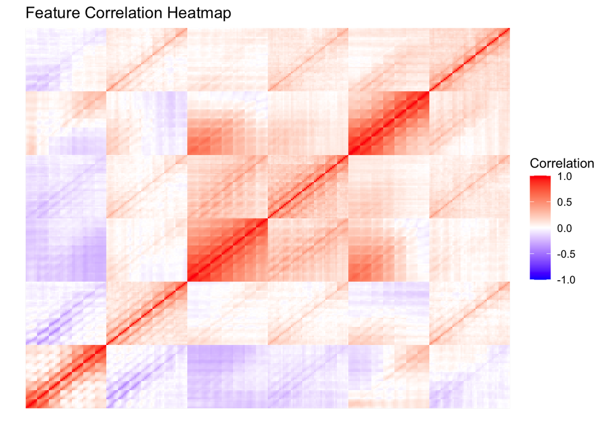

```r
# Get correlation matrix
cor_matrix <- cor(data[,-(295:300)])

# Turn matrix into long format
cor_df <- melt(cor_matrix, varnames = c("Feature1", "Feature2"), value.name = "Correlation")

# Plot correlation heat map
ggplot(cor_df, aes(x = Feature1, y = Feature2, fill = Correlation)) +
  geom_tile() +
  scale_fill_gradient2(low = "blue", high = "red", mid = "white",
                       midpoint = 0, limit = c(-1, 1), space = "Lab",
                       name = "Correlation") +
  theme_minimal() +
  theme(
    axis.text.x = element_blank(),  # remove x-axis text
    axis.text.y = element_blank(),  # remove y-axis text
    axis.ticks = element_blank(),   # remove axis ticks
    legend.position = "right"
  ) +
  labs(title = "Feature Correlation Heatmap", x = "", y = "")
```

#### We see that along the diagonal there is some strong correlation among features, however, most of the features seem to have vorrelations closer to 0. Next, we compare several multilabel classification models. The Transformation models used are Binary relevance, classifier chains, label powerset and calibrated label ranking. The multi label k-nearest neighours is used as an adaptaion model. For ensemble methods, ensemble binary relevance and ensemble classifier chains are used. For the transformation and ensemble methods, random forests are used as the base model for comparison purposes.

```r
# train/test split
set.seed(123)
train_indices <- sort(sample(1:nrow(data), size = 1211, replace = FALSE), decreasing = F)
data_train <- data[train_indices,]
data_test <- data[-train_indices,]
data_train_mldr <- mldr_from_dataframe(data_train, labelIndices = label_indices, name = "scene train")
data_test_mldr <- mldr_from_dataframe(data_test, labelIndices = label_indices, name = "scene test")
```

## Model Fitting

```r
# Binary relevance with RF
br_fit <- br(data_train_mldr, base.algorithm = "RF", cores = 6)
train_br_predict <- ifelse(predict(br_fit, data_train_mldr)>0.5,1,0)
test_br_predict <- ifelse(predict(br_fit, data_test_mldr)>0.5,1,0)

# Classifier Chains with RF
cc_fit <- cc(data_train_mldr, base.algorithm = "RF", cores = 6)
train_cc_predict <- ifelse(predict(cc_fit, data_train_mldr)>0.5,1,0)
test_cc_predict <- ifelse(predict(cc_fit, data_test_mldr)>0.5,1,0)

# Label powerset with RF
lp_fit <- lp(data_train_mldr, base.algorithm = "RF", cores = 6)
train_lp_predict <- ifelse(predict(lp_fit, data_train_mldr)>0.5,1,0)
test_lp_predict <- ifelse(predict(lp_fit, data_test_mldr)>0.5,1,0)

# Calibrated label ranking with RF
clr_fit <- clr(data_train_mldr, base.algorithm = "RF", cores = 6)
train_clr_predict <- ifelse(predict(clr_fit, data_train_mldr)>0.5,1,0)
test_clr_predict <- ifelse(predict(clr_fit, data_test_mldr)>0.5,1,0)

# Multi-label knn
mlknn_fit <- mlknn(data_train_mldr)
train_mlknn_predict <- ifelse(predict(mlknn_fit, data_train_mldr)>0.5,1,0)
test_mlknn_predict <- ifelse(predict(mlknn_fit, data_test_mldr)>0.5,1,0)

# Ensemble binary relevance with RF
ebr_fit <- ebr(data_train_mldr, base.algorithm = "RF", cores = 6)
train_ebr_predict <- ifelse(predict(ebr_fit, data_train_mldr)>0.5,1,0)
test_ebr_predict <- ifelse(predict(ebr_fit, data_test_mldr)>0.5,1,0)

# Ensemble classifier Chains with RF
ecc_fit <- ecc(data_train_mldr, base.algorithm = "RF", cores = 6)
train_ecc_predict <- ifelse(predict(ecc_fit, data_train_mldr)>0.5,1,0)
test_ecc_predict <- ifelse(predict(ecc_fit, data_test_mldr)>0.5,1,0)
```

```r
### Example metrics
# Hamming loss
hamming_loss <- function(pred, true){
  return(mean(abs(true - pred)))
}

# Accuracy
accuracy <- function(pred, true) {
  return(mean(rowSums(pred & true) / rowSums(pred | true)))
}

# subset accuracy
subset_accuracy <- function(pred, true) {
  return(mean(apply(pred == true, 1, all)))
}

# Precision
precision <- function(pred, true) {
  true_positives <- rowSums(pred & true)
  predicted_positives <- rowSums(pred)
  predicted_positives[predicted_positives == 0] <- 1 # this ensures we don't get NaN's i.e. don't divide by 0
  return(mean(true_positives / predicted_positives))
}

# recall
recall <- function(pred, true) {
  true_positives <- rowSums(pred & true)
  possible_positives <- rowSums(true)
  return(mean(true_positives / possible_positives))
}

# f1 score
f1 <- function(pred, true) {
  precision <- precision(pred, true)
  recall <- recall(pred, true)
  return(2 * precision * recall / (precision + recall))
}
```

```r
# labels as matrices
train_true_labels <- as.matrix(data_train[,(295:300)])
test_true_labels <- as.matrix(data_test[,(295:300)])

# lists of metrics and models for output
metrics <- c( "accuracy", "subset_accuracy", "hamming_loss", "precision", "recall", "f1")

train_predictions <- list(
  "binary relevance" = train_br_predict,
  "classifier chains" = train_cc_predict,
  "label powerset" = train_lp_predict,
  "calibrated label ranking" = train_clr_predict,
  "multilabel k-NN" = train_mlknn_predict,
  "ensemble binary relevance" = train_ebr_predict,
  "ensemble classifier chains" = train_ecc_predict
)

test_predictions <- list(
  "binary relevance" = test_br_predict,
  "classifier chains" = test_cc_predict,
  "label powerset" = test_lp_predict,
  "calibrated label ranking" = test_clr_predict,
  "multilabel k-NN" = test_mlknn_predict,
  "ensemble binary relevance" = test_ebr_predict,
  "ensemble classifier chains" = test_ecc_predict
)

# Function to get metrics for model results
evaluate_models <- function(predictions, true_labels, metrics) {
  results <- data.frame(matrix(nrow = 0, ncol = length(metrics)))
  colnames(results) <- metrics
  for (model_name in names(predictions)) {
    pred <- as.matrix(predictions[[model_name]])
    row <- sapply(metrics, function(m) {
      metric_fn <- get(m)  # get function by name
      suppressWarnings(metric_fn(pred, true_labels))  # suppress divide-by-zero warnings
    })
    results <- rbind(results, row)
  }
  rownames(results) <- names(predictions)
  return(results)
}

# Get train and test results
train_results <- evaluate_models(train_predictions, train_true_labels, metrics)
colnames(train_results) <- metrics
test_results <- evaluate_models(test_predictions, test_true_labels, metrics)
colnames(test_results) <- metrics
print(t(round(train_results, 3)))
```

```
##                 binary relevance classifier chains label powerset
## accuracy                       1                 1              1
## subset_accuracy                1                 1              1
## hamming_loss                   0                 0              0
## precision                      1                 1              1
## recall                         1                 1              1
## f1                             1                 1              1
##                 calibrated label ranking multilabel k-NN
## accuracy                           0.551           0.721
## subset_accuracy                    0.102           0.672
## hamming_loss                       0.150           0.072
## precision                          0.551           0.750
## recall                             1.000           0.742
## f1                                 0.711           0.746
##                 ensemble binary relevance ensemble classifier chains
## accuracy                            0.902                      0.902
## subset_accuracy                     0.884                      0.882
## hamming_loss                        0.023                      0.024
## precision                           0.919                      0.923
## recall                              0.903                      0.902
## f1                                  0.911                      0.913
```

```r
print(t(round(test_results, 3)))
```

```
##                 binary relevance classifier chains label powerset
## accuracy                   0.580             0.601          0.457
## subset_accuracy            0.557             0.579          0.446
## hamming_loss               0.086             0.084          0.105
## precision                  0.599             0.620          0.466
## recall                     0.584             0.604          0.457
## f1                         0.591             0.612          0.461
##                 calibrated label ranking multilabel k-NN
## accuracy                           0.495           0.656
## subset_accuracy                    0.070           0.619
## hamming_loss                       0.183           0.094
## precision                          0.498           0.676
## recall                             0.919           0.675
## f1                                 0.646           0.675
##                 ensemble binary relevance ensemble classifier chains
## accuracy                            0.750                      0.752
## subset_accuracy                     0.720                      0.724
## hamming_loss                        0.076                      0.075
## precision                           0.776                      0.779
## recall                              0.753                      0.753
## f1                                  0.764                      0.766
```

```r
# Define the metrics to extract
metrics <- c("hamming_loss", "accuracy", "subset_accuracy", "precision", "recall", "fmeasure")



# Helper to extract and structure metrics
extract_metrics <- function(results_list, metrics) {
  do.call(rbind, lapply(names(results_list), function(name) {
    row <- results_list[[name]][metrics]
    # Ensure missing values (e.g., NULL) are NA
    row <- sapply(metrics, function(m) ifelse(is.null(row[[m]]), NA, row[[m]]))
    data.frame(Model = name, t(row), check.names = FALSE)
  }))
}

# # Generate the two tables
# example_table <- extract_metrics(results_list, example_metrics)
# macro_micro_table <- extract_metrics(results_list, macro_micro_metrics)
#
# # Print tables
# print(example_table)
# print(macro_micro_table)
```

## References

#### Boutell, M.R., Luo, J., Shen, X. and Brown, C.M. (2004). Learning multi-label scene classification. Pattern recognition, vol. 37, no. 9, pp. 1757–1771.

#### Charte, F., Rivera, A.J., del Jesus, M.J. and Herrera, F. (2019). Dealing with difficult minority labels in imbalanced mutilabel data sets. Neurocomputing, vol. 326, pp. 39–53.